# Descriptive Statistics and Visualization with R

Author

Boro, Binya Benson Abe

1. Dataset: school_spending.dta

The dataset is “school_spending.dta.” It consists of observations on school expenditure and pupil’s performance.

2. Data cleaning

The variable attributes/labels are in German. They were translated into English.

```r
## Import cleaned data
sch_spending <- read_dta(here("data/cleaned_educ_spending.dta"))

## summary statistics of key variables

datasummary(
  testscr + expn_stu + str + meal_pct + comp_stu + avginc + el_pct ~
    Mean + SD + Min + Max + N,
  data = sch_spending,
  fmt = 2,
  title = "Table 1: Summary Statistics"
  )
```

Table 1: Summary Statistics

|  | Mean | SD | Min | Max | N |
| --- | --- | --- | --- | --- | --- |
| testscr | 654.16 | 19.05 | 605.55 | 706.75 | 420 |
| expn_stu | 5312.41 | 633.94 | 3926.07 | 7711.51 | 420 |
| str | 19.64 | 1.89 | 14.00 | 25.80 | 420 |
| meal_pct | 44.71 | 27.12 | 0.00 | 100.00 | 420 |
| comp_stu | 0.14 | 0.06 | 0.00 | 0.42 | 420 |
| avginc | 15.32 | 7.23 | 5.34 | 55.33 | 420 |
| el_pct | 15.77 | 18.29 | 0.00 | 85.54 | 420 |

4. Data visualization with ggplot2

First, I used histograms to analyse the key variables of interest, average test score - testscr and expenditure per pupil - expn_stu. Then, I used graphical methods to analyse the relationship between average test scores and income, food vouchers, pupil-teacher ratio, non-native English speakers, among others. I applied esquisser from the esquisse package to build the ggplot2 graphs and code.

1. The distribution of Pupil’s Average Test Scores

The distribution of pupil’s average test scores is approximately symmetric around the mean. Most pupil’s test scores cluster around 660 points, suggesting an even distribution of pupil’s performance across all districts.

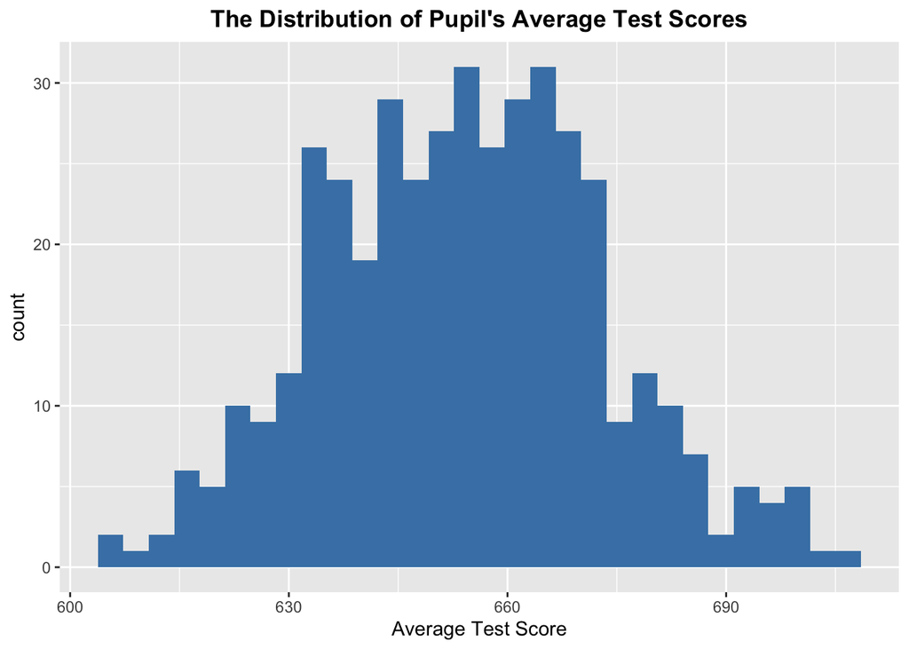

```r
#esquisser(sch_spending) # esquisser creates ggplot2 graphs and their codes

ggplot(sch_spending) +
  aes(x = testscr) +
  geom_histogram(bins = 30L, fill = "steelblue") +
  labs(
    x = "Average Test Score",
    title = "The Distribution of Pupil's Average Test Scores"
  ) +
  theme_gray() +
  theme(plot.title = element_text(face = "bold", hjust = 0.5))
```

```r
# export figure
    ggsave(here("output/hist_testscr.png"),
      width = 7,
      height = 5,
      dpi = 300
    )
```

2. The distribution of Expenditure Per Pupil

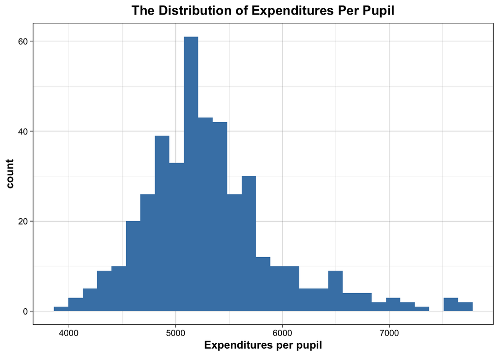

```r
    #| label: hist of expn_stu
    #| echo: true
    #| message: false
    #| warning: false
    ggplot(sch_spending) +
      aes(x = expn_stu) +
      geom_histogram(bins = 29L, fill = "steelblue") +
      labs(title = "The Distribution of Expenditures Per Pupil") +
      theme_linedraw() +
      theme(
        plot.title = element_text(face = "bold",
        hjust = 0.5),
        axis.title.y = element_text(face = "bold"),
        axis.title.x = element_text(face = "bold"),
        legend.title = element_text(face = "bold")
      )
```

```r
  # export figure
    ggsave(here("output/hist.expn.png"),
      width = 7,
      height = 5,
      dpi = 300
    )
```

3. Relationship Between Income and Pupil’s Performance

The relationship between average income and pupil’s average test score is positive. In addition, the regression line is upward sloping, implying that districts with higher average incomes tend to have higher pupil’s test scores.

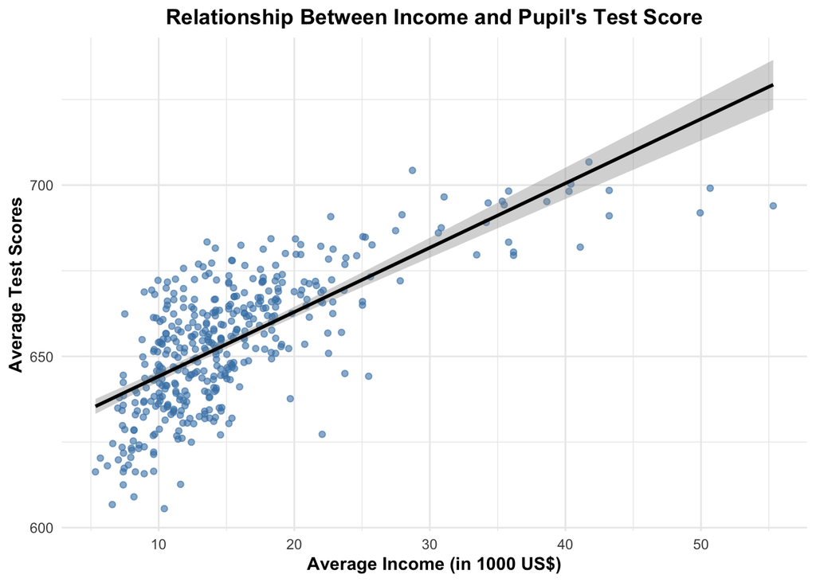

```r
    #| label: testscr&avginc
    #| echo: true
    #| message: false
    #| warning: false
    ggplot(sch_spending) +
      aes(x = avginc, y = testscr) +
      geom_point(colour = "steelblue", alpha = 0.6) +
      geom_smooth(method = "lm", color = "black", se = TRUE) +
      labs(
        x = "Average Income (in 1000 US$)",
        title = "Relationship Between Income and Pupil's Test Score"
      ) +
      theme_minimal() +
      theme(
        plot.title = element_text(face = "bold",
        hjust = 0.5),
        axis.title.y = element_text(face = "bold"),
        axis.title.x = element_text(face = "bold")
      )
```

```r
  # export figure
    ggsave(here("output/figInc_testscr.png"),
      width = 7,
      height = 5,
      dpi = 300
    )
```

4. Relationship Between Meal Vouchers and Pupil’s Performance

There is a negative association between the share of pupil’s with meal vouchers and pupil’s average test scores. The regression line is downward sloping, suggesting that schools with a high percentage of pupil’s with food vouchers tend to record poor average test scores.

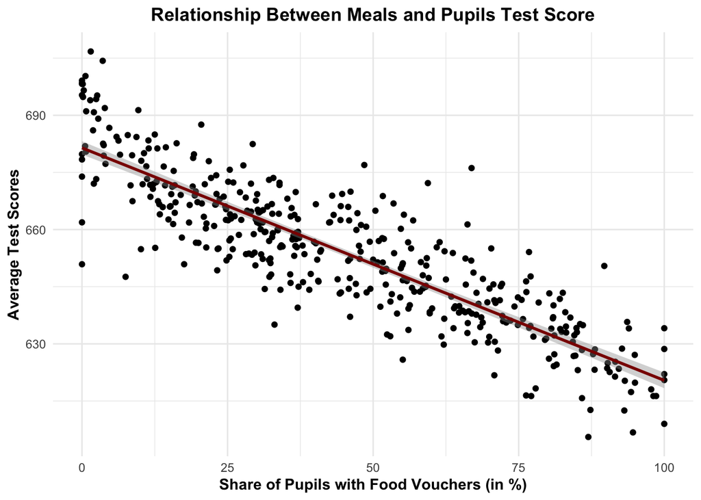

```r
    #| label: meals&testscr
    #| echo: true
    #| message: false
    #| warning: false

    ggplot(sch_spending) +
      aes(x = meal_pct, y = testscr) +
      geom_point(shape = "circle", colour = "black") +
      geom_smooth(method = "lm", color = "darkred", se = TRUE) +
      labs(
        x = "Share of Pupils with Food Vouchers (in %)",
        title = "Relationship Between Meals and Pupils Test Score"
      ) +
      theme_minimal() +
      theme(
        plot.title = element_text(face = "bold",
        hjust = 0.5),
        axis.title.y = element_text(face = "bold"),
        axis.title.x = element_text(face = "bold")
      )
```

```r
  # export figure
    ggsave(here("output/figMeal_testscr.png"),
      width = 7,
      height = 5,
      dpi = 300
    )
```

5. Relationship between Expenditure and Pupil’s Test Scores

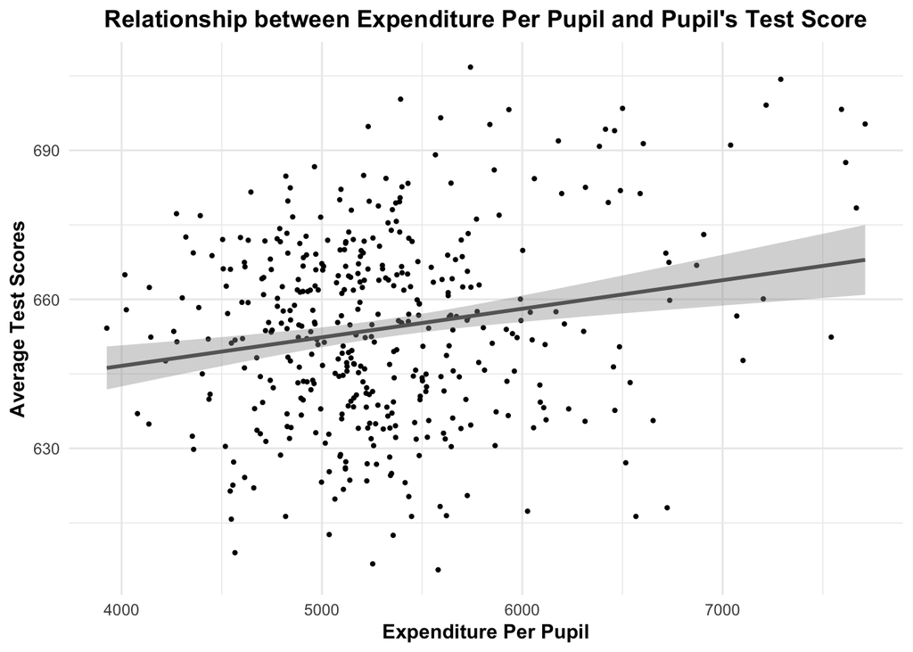

```r
    #| label: expn_stu&testscr
    #| echo: true
    ggplot(sch_spending) +
      aes(x = expn_stu, y = testscr) +
      geom_point(
        size = 1.25,
        shape = "bullet",
        colour = "black"
      ) +
      geom_smooth(method = "lm", color = "gray40", se = TRUE) +
      labs(
        x = "Expenditure Per Pupil",
        title = "Relationship between Expenditure Per Pupil and Pupil's Test Score"
      ) +
      theme_minimal() +
      theme(
        plot.title = element_text(face = "bold",
        hjust = 0.5),
        axis.title.y = element_text(face = "bold"),
        axis.title.x = element_text(face = "bold")
      )
```

```r
    # export figure
    ggsave(here("output/figExpn_testscr.png"),
      width = 7,
      height = 5,
      dpi = 300
    )
```

6. Relationship between Non-native English Speakers and Pupil’s Performance.

There is a negative association between the share of non-native English speakers and pupil’s average test scores: The regression line is downward sloping, implying that having non-native English speakers tend to worsen pupil’s test scores.

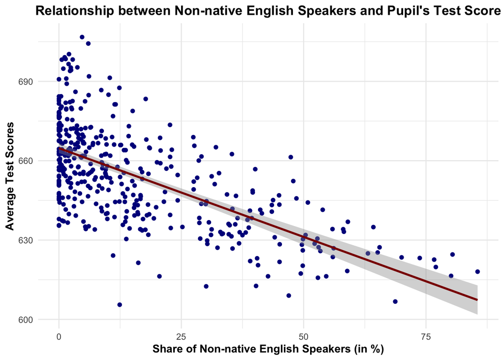

```r
    #| label: el_pct&testscr
    #| echo: true
    #| message: false
    #| warning: false

    ggplot(sch_spending) +
      aes(x =el_pct, y = testscr) +
      geom_point(shape = "circle", colour = "darkblue") +
      geom_smooth(method = "lm", color = "darkred", se = TRUE) +
      labs(
        x = "Share of Non-native English Speakers (in %)",
        title = "Relationship between Non-native English Speakers and Pupil's Test Score"
      ) +
      theme_minimal() +
      theme(
        plot.title = element_text(face = "bold",
        hjust = 0.5),
        axis.title.y = element_text(face = "bold"),
        axis.title.x = element_text(face = "bold")
      )
```

```r
  # export figure
    ggsave(here("output/figElpct_testscr.png"),
      width = 7,
      height = 5,
      dpi = 300
    )
```

7. Relationship between Computer and Pupil’s Performance

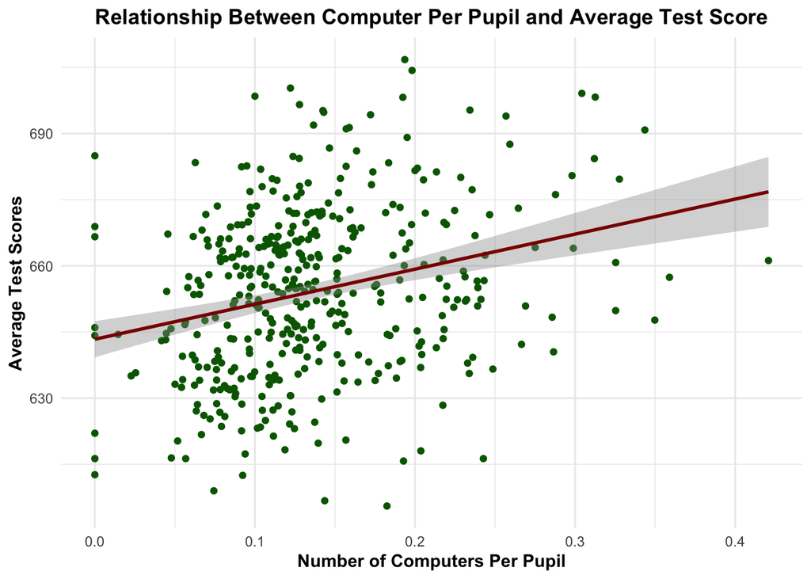

```r
    #| label: comp_stu&testscr
    #| echo: true
    #| message: false
    #| warning: false

    ggplot(sch_spending) +
      aes(x = comp_stu, y =testscr) +
      geom_point(shape = "circle", colour = "darkgreen") +
      geom_smooth(method = "lm", color = "darkred", se = TRUE) +
      labs(
        x = "Number of Computers Per Pupil",
        title = "Relationship Between Computer Per Pupil and Average Test Score"
      ) +
      theme_minimal() +
      theme(
        plot.title = element_text(face = "bold",
        hjust = 0.5),
        axis.title.y = element_text(face = "bold"),
        axis.title.x = element_text(face = "bold")
      )
```

```r
# export figure
    ggsave(here("output/figComp_testscr.png"),
      width = 7,
      height = 5,
      dpi = 300
    )
```